# Business Case: Walmart - Confidence Interval and CLT

Description Walmart

Walmart is an American multinational retail corporation that operates a chain of supercenters, discount departmental stores, and grocery stores from the United States. Walmart has more than 100 million customers worldwide.

Walmart Inc. is an American multinational retail corporation that operates a chain of hypermarkets, discount department stores, and grocery stores in the United States, headquartered in Bentonville, Arkansas.

```python
import numpy as np
import pandas as pd
import seaborn as sns
import matplotlib.pyplot as plt
from scipy.stats import norm
```

### READING A FILE

```python
df=pd.read_csv('WalMart.csv')
df
```

|  | User_ID | Product_ID | Gender | Age | Occupation | City_Category | Stay_In_Current_City_Years | Marital_Status | Product_Category | Purchase |
| --- | --- | --- | --- | --- | --- | --- | --- | --- | --- | --- |
| 0 | 1000001 | P00069042 | F | 0-17 | 10 | A | 2 | 0 | 3 | 8370 |
| 1 | 1000001 | P00248942 | F | 0-17 | 10 | A | 2 | 0 | 1 | 15200 |
| 2 | 1000001 | P00087842 | F | 0-17 | 10 | A | 2 | 0 | 12 | 1422 |
| 3 | 1000001 | P00085442 | F | 0-17 | 10 | A | 2 | 0 | 12 | 1057 |
| 4 | 1000002 | P00285442 | M | 55+ | 16 | C | 4+ | 0 | 8 | 7969 |
| ... | ... | ... | ... | ... | ... | ... | ... | ... | ... | ... |
| 550063 | 1006033 | P00372445 | M | 51-55 | 13 | B | 1 | 1 | 20 | 368 |
| 550064 | 1006035 | P00375436 | F | 26-35 | 1 | C | 3 | 0 | 20 | 371 |
| 550065 | 1006036 | P00375436 | F | 26-35 | 15 | B | 4+ | 1 | 20 | 137 |
| 550066 | 1006038 | P00375436 | F | 55+ | 1 | C | 2 | 0 | 20 | 365 |
| 550067 | 1006039 | P00371644 | F | 46-50 | 0 | B | 4+ | 1 | 20 | 490 |

550068 rows × 10 columns

### HEAD OF DATA

```python
df.head()
```

|  | User_ID | Product_ID | Gender | Age | Occupation | City_Category | Stay_In_Current_City_Years | Marital_Status | Product_Category | Purchase |
| --- | --- | --- | --- | --- | --- | --- | --- | --- | --- | --- |
| 0 | 1000001 | P00069042 | F | 0-17 | 10 | A | 2 | 0 | 3 | 8370 |
| 1 | 1000001 | P00248942 | F | 0-17 | 10 | A | 2 | 0 | 1 | 15200 |
| 2 | 1000001 | P00087842 | F | 0-17 | 10 | A | 2 | 0 | 12 | 1422 |
| 3 | 1000001 | P00085442 | F | 0-17 | 10 | A | 2 | 0 | 12 | 1057 |
| 4 | 1000002 | P00285442 | M | 55+ | 16 | C | 4+ | 0 | 8 | 7969 |

### TAIL OF DATA

```python
df.tail()
```

|  | User_ID | Product_ID | Gender | Age | Occupation | City_Category | Stay_In_Current_City_Years | Marital_Status | Product_Category | Purchase |
| --- | --- | --- | --- | --- | --- | --- | --- | --- | --- | --- |
| 550063 | 1006033 | P00372445 | M | 51-55 | 13 | B | 1 | 1 | 20 | 368 |
| 550064 | 1006035 | P00375436 | F | 26-35 | 1 | C | 3 | 0 | 20 | 371 |
| 550065 | 1006036 | P00375436 | F | 26-35 | 15 | B | 4+ | 1 | 20 | 137 |
| 550066 | 1006038 | P00375436 | F | 55+ | 1 | C | 2 | 0 | 20 | 365 |
| 550067 | 1006039 | P00371644 | F | 46-50 | 0 | B | 4+ | 1 | 20 | 490 |

### To check the first and last 5 rows together.

```python
df[['User_ID','Product_ID']].head().append(df[['User_ID','Product_ID']].tail())
```

|  | User_ID | Product_ID |
| --- | --- | --- |
| 0 | 1000001 | P00069042 |
| 1 | 1000001 | P00248942 |
| 2 | 1000001 | P00087842 |
| 3 | 1000001 | P00085442 |
| 4 | 1000002 | P00285442 |
| 550063 | 1006033 | P00372445 |
| 550064 | 1006035 | P00375436 |
| 550065 | 1006036 | P00375436 |
| 550066 | 1006038 | P00375436 |
| 550067 | 1006039 | P00371644 |

### LENGTH OF DATA

```python
len(df)
```

```
550068
```

### SHAPE OF DATA

```python
df.shape
```

```
(550068, 10)
```

### SIZE OF DATA

```python
df.size
```

```
5500680
```

### ANALYTICAL DESCRIPTION OF DATA

```python
df.describe()
```

|  | User_ID | Occupation | Marital_Status | Product_Category | Purchase |
| --- | --- | --- | --- | --- | --- |
| count | 5.500680e+05 | 550068.000000 | 550068.000000 | 550068.000000 | 550068.000000 |
| mean | 1.003029e+06 | 8.076707 | 0.409653 | 5.404270 | 9263.968713 |
| std | 1.727592e+03 | 6.522660 | 0.491770 | 3.936211 | 5023.065394 |
| min | 1.000001e+06 | 0.000000 | 0.000000 | 1.000000 | 12.000000 |
| 25% | 1.001516e+06 | 2.000000 | 0.000000 | 1.000000 | 5823.000000 |
| 50% | 1.003077e+06 | 7.000000 | 0.000000 | 5.000000 | 8047.000000 |
| 75% | 1.004478e+06 | 14.000000 | 1.000000 | 8.000000 | 12054.000000 |
| max | 1.006040e+06 | 20.000000 | 1.000000 | 20.000000 | 23961.000000 |

Statement:The table presents key statistics for various attributes in a dataset, likely related to retail transactions. The dataset comprises 550,068 entries with User IDs ranging from 1,000,001 to 1,006,040. On average, customers have an occupation code of approximately 8, and a little over 40% are married. The most common product category is 5, and the average purchase amount is $9,263.97, with a significant standard deviation of $5,023.07. These statistics provide insights into customer demographics and their purchasing behaviors, aiding businesses in targeting and pricing strategies.

### ANALYTICAL DESCRIPTION OF DATA WITH OBJECT DATA TYPE

```python
df.describe(include="object")
```

|  | Product_ID | Gender | Age | City_Category | Stay_In_Current_City_Years |
| --- | --- | --- | --- | --- | --- |
| count | 550068 | 550068 | 550068 | 550068 | 550068 |
| unique | 3631 | 2 | 7 | 3 | 5 |
| top | P00265242 | M | 26-35 | B | 1 |
| freq | 1880 | 414259 | 219587 | 231173 | 193821 |

### CHECKING NULL VALUES

```python
df.isna().sum()
```

```
User_ID                       0
Product_ID                    0
Gender                        0
Age                           0
Occupation                    0
City_Category                 0
Stay_In_Current_City_Years    0
Marital_Status                0
Product_Category              0
Purchase                      0
dtype: int64
```

### INFORMATION OF DATA

```python
df.info()
```

```
<class 'pandas.core.frame.DataFrame'>
RangeIndex: 550068 entries, 0 to 550067
Data columns (total 10 columns):
 #   Column                      Non-Null Count   Dtype
---  ------                      --------------   -----
 0   User_ID                     550068 non-null  int64
 1   Product_ID                  550068 non-null  object
 2   Gender                      550068 non-null  object
 3   Age                         550068 non-null  object
 4   Occupation                  550068 non-null  int64
 5   City_Category               550068 non-null  object
 6   Stay_In_Current_City_Years  550068 non-null  object
 7   Marital_Status              550068 non-null  int64
 8   Product_Category            550068 non-null  int64
 9   Purchase                    550068 non-null  int64
dtypes: int64(5), object(5)
memory usage: 42.0+ MB
```

### COLUMNS INCLUDES

```python
df.keys()
```

```
Index(['User_ID', 'Product_ID', 'Gender', 'Age', 'Occupation', 'City_Category',
       'Stay_In_Current_City_Years', 'Marital_Status', 'Product_Category',
       'Purchase'],
      dtype='object')
```

```python
columns =['Age','Gender','City_Category','Stay_In_Current_City_Years','Marital_Status']
df[columns].melt().groupby(['variable','value'])[['value']].count()/len(df)
```

| variable | value | value |
| --- | --- | --- |
| Age | 0-17 | 0.027455 |
|  | 18-25 | 0.181178 |
|  | 26-35 | 0.399200 |
|  | 36-45 | 0.199999 |
|  | 46-50 | 0.083082 |
|  | 51-55 | 0.069993 |
|  | 55+ | 0.039093 |
| City_Category | A | 0.268549 |
|  | B | 0.420263 |
|  | C | 0.311189 |
| Gender | F | 0.246895 |
|  | M | 0.753105 |
| Marital_Status | 0 | 0.590347 |
|  | 1 | 0.409653 |
| Stay_In_Current_City_Years | 0 | 0.135252 |
|  | 1 | 0.352358 |
|  | 2 | 0.185137 |
|  | 3 | 0.173224 |
|  | 4+ | 0.154028 |

Statement:The provided dataset offers insights into the purchasing behavior of a population. Notably, the majority of shoppers are male (75.31%), with a significant portion falling into the 26-35 age group (39.92%). Shoppers from City Category B (42.03%) dominate, while most customers are unmarried (59.03%). Interestingly, a substantial proportion of customers have been staying in their current city for less than a year (13.53%). These demographics can inform marketing and product strategies for businesses targeting this customer base.

```python
df[:3]
```

|  | User_ID | Product_ID | Gender | Age | Occupation | City_Category | Stay_In_Current_City_Years | Marital_Status | Product_Category | Purchase |
| --- | --- | --- | --- | --- | --- | --- | --- | --- | --- | --- |
| 0 | 1000001 | P00069042 | F | 0-17 | 10 | A | 2 | 0 | 3 | 8370 |
| 1 | 1000001 | P00248942 | F | 0-17 | 10 | A | 2 | 0 | 1 | 15200 |
| 2 | 1000001 | P00087842 | F | 0-17 | 10 | A | 2 | 0 | 12 | 1422 |

### Observing the users data with categories

### Gender Contribution

```python
Genders = df.groupby(by=['User_ID'])['Gender'].unique()
Genders.value_counts()/len(Genders)*100
```

```
[M]    71.719572
[F]    28.280428
Name: Gender, dtype: float64
```

Statement: The provided data shows that the majority of customers in the dataset are male (71.72%), while females represent a smaller portion (28.28%). This gender distribution can inform marketing and product strategies to better cater to the predominantly male customer base.

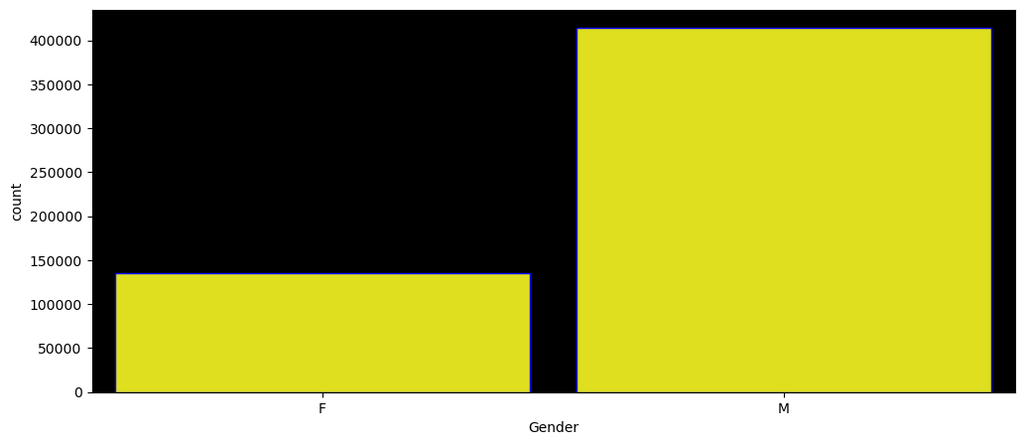

```python
plt.figure(figsize=(12,5), dpi=100)
bar = sns.countplot(data=df, x='Gender', color="yellow",ec="b",width=0.9)
ax=plt.gca()
ax.set_facecolor('black')
plt.show()
```

### Age Contribution

```python
Age = df.groupby(by=['User_ID'])['Age'].unique()
Age.value_counts()/len(Age)*100
```

```
[26-35]    34.849771
[36-45]    19.809879
[18-25]    18.146325
[46-50]     9.013750
[51-55]     8.164997
[55+]       6.314717
[0-17]      3.700560
Name: Age, dtype: float64
```

Statement: The data reveals that the largest customer age group is 26-35, comprising 34.85% of the dataset, followed by 36-45 at 19.81%. Younger age groups (18-25 and 0-17) make up a smaller portion, while older groups (46-55 and 55+) collectively represent a substantial portion, highlighting the diverse age demographics among customers.

### Marital Status contribution

```python
Marital_Status = df.groupby(by=['User_ID'])['Marital_Status'].unique()
Marital_Status.value_counts()/len(Marital_Status)
```

```
[0]    0.580037
[1]    0.419963
Name: Marital_Status, dtype: float64
```

Statement: The data indicates that the majority of customers have a Marital_Status of 0 (unmarried), accounting for 58.00%, while 41.99% are married (Marital_Status 1). This shows a higher prevalence of unmarried individuals in the dataset and can guide marketing strategies and product offerings accordingly.

## Cities Behaviour

```python
city= df.groupby(by=['User_ID'])['City_Category'].unique()
city.value_counts()/len(city)*100
```

```
[C]    53.284672
[B]    28.976405
[A]    17.738924
Name: City_Category, dtype: float64
```

### Genders contributing Purchase

```python
purchase_sample = pd.DataFrame(df.groupby(by=['Gender'])['Purchase'].sum())
purchase_sample
```

| Gender | Purchase |
| --- | --- |
| F | 1186232642 |
| M | 3909580100 |

Statement: In purchase data, males (M) outspent females (F) significantly, with males contributing $3,909,580,100 compared to females' $1,186,232,642, indicating a gender-based spending disparity favoring males.

```python
purchase_sample['percentage'] = purchase_sample['Purchase']/purchase_sample['Purchase'].sum()*100
purchase_sample
```

| Gender | Purchase | percentage |
| --- | --- | --- |
| F | 1186232642 | 23.278576 |
| M | 3909580100 | 76.721424 |

Statement:The table illustrates gender-based purchase percentages. Males (M) dominate, accounting for 76.72% of total purchases, significantly surpassing females (F) who contribute only 23.28%. This highlights a substantial gender disparity in purchasing behavior, with males being the primary consumers.

### Average Contribution of Male and Female in Purchase

```python
female = df[df['Gender']=="F"]['Purchase'].mean()
print("Female Average spending:",female)
male = df[df['Gender']=="M"]['Purchase'].mean()
print("Male Average Spending:",male)
```

```
Female Average spending: 8734.565765155476
Male Average Spending: 9437.526040472265
```

Statement: On average, male customers spend more (9437.53) compared to female customers (8734.57). This suggests that tailoring marketing strategies and product offerings to male preferences could potentially boost revenue and profitability.

### Insights of Cities with Ages

```python
pd.crosstab(index=df['City_Category'], columns=df['Age'],margins=True,normalize=True)
```

| Age City_Category | 0-17 | 18-25 | 26-35 | 36-45 | 46-50 | 51-55 | 55+ | All |
| --- | --- | --- | --- | --- | --- | --- | --- | --- |
| A | 0.004625 | 0.050057 | 0.134065 | 0.048389 | 0.013829 | 0.011088 | 0.006496 | 0.268549 |
| B | 0.009881 | 0.078621 | 0.166496 | 0.086531 | 0.037097 | 0.032252 | 0.009384 | 0.420263 |
| C | 0.012949 | 0.052499 | 0.098639 | 0.065079 | 0.032156 | 0.026653 | 0.023213 | 0.311189 |
| All | 0.027455 | 0.181178 | 0.399200 | 0.199999 | 0.083082 | 0.069993 | 0.039093 | 1.000000 |

### Insights of Genders with Ages

```python
pd.crosstab(index=df['Gender'],columns=df['Age'],normalize=True,margins=True)
```

| Age Gender | 0-17 | 18-25 | 26-35 | 36-45 | 46-50 | 51-55 | 55+ | All |
| --- | --- | --- | --- | --- | --- | --- | --- | --- |
| F | 0.009241 | 0.044773 | 0.092265 | 0.049394 | 0.023995 | 0.017987 | 0.009241 | 0.246895 |
| M | 0.018214 | 0.136405 | 0.306935 | 0.150605 | 0.059087 | 0.052006 | 0.029853 | 0.753105 |
| All | 0.027455 | 0.181178 | 0.399200 | 0.199999 | 0.083082 | 0.069993 | 0.039093 | 1.000000 |

### Contribution of segment Age with purchase value

```python
Ages = pd.DataFrame(df.groupby('Age')['Purchase'].sum())
Ages
```

| Age | Purchase |
| --- | --- |
| 0-17 | 134913183 |
| 18-25 | 913848675 |
| 26-35 | 2031770578 |
| 36-45 | 1026569884 |
| 46-50 | 420843403 |
| 51-55 | 367099644 |
| 55+ | 200767375 |

Statement: This table shows purchase amounts by age groups. The 26-35 age group has the highest spending, totaling $2,031,770,578, while the 0-17 and 55+ age groups exhibit the lowest spending, with $134,913,183 and $200,767,375, respectively.

```python
Ages['percentage'] = Ages['Purchase']/Ages['Purchase'].sum()*100
Ages
```

| Age | Purchase | percentage |
| --- | --- | --- |
| 0-17 | 134913183 | 2.647530 |
| 18-25 | 913848675 | 17.933325 |
| 26-35 | 2031770578 | 39.871374 |
| 36-45 | 1026569884 | 20.145361 |
| 46-50 | 420843403 | 8.258612 |
| 51-55 | 367099644 | 7.203947 |
| 55+ | 200767375 | 3.939850 |

Statement: This table displays purchase percentages across various age groups. The 26-35 age group makes the largest contribution to purchases, accounting for 39.87% of total spending. Notably, the 18-25 age range also has a substantial share at 17.93%. Older age groups, such as 36-45, 46-50, and 51-55, exhibit moderate buying behavior. The 0-17 and 55+ age groups have the smallest purchasing shares at 2.65% and 3.94%, respectively, indicating varying spending patterns among different age demographics.

### Contribution of segment Marital_status with purchase value

```python
Marital_status = pd.DataFrame(df.groupby('Marital_Status')['Purchase'].sum())
Marital_status['percenatge'] = Marital_status['Purchase']/Marital_status['Purchase'].sum()*100
Marital_status
```

| Marital_Status | Purchase | percenatge |
| --- | --- | --- |
| 0 | 3008927447 | 59.047057 |
| 1 | 2086885295 | 40.952943 |

Statement: From a business perspective, this data suggests that the majority of purchases come from individuals with a marital status of 0 (single or unmarried), contributing 59.05% of total spending. This insight can help businesses tailor marketing and product strategies to effectively target and engage both single and married customers, optimizing revenue streams.

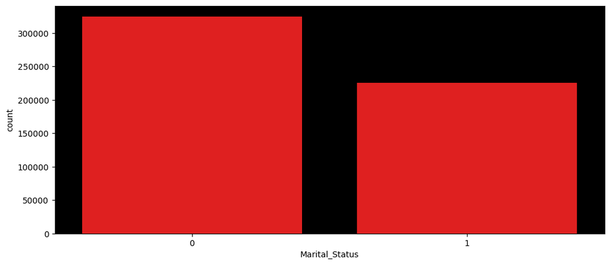

```python
plt.figure(figsize=(12,5))
sns.countplot(data=df, x='Marital_Status', color="Red")
ax=plt.gca()
ax.set_facecolor('black')
plt.show()
```

### Contribution of segment City Segments with purchase value

```python
city = pd.DataFrame(df.groupby('City_Category')['Purchase'].sum())
city['percenatge'] = city['Purchase']/city['Purchase'].sum()*100
city["Average"] = city['Purchase'].mean()
city
```

| City_Category | Purchase | percenatge | Average |
| --- | --- | --- | --- |
| A | 1316471661 | 25.834381 | 1.698604e+09 |
| B | 2115533605 | 41.515136 | 1.698604e+09 |
| C | 1663807476 | 32.650483 | 1.698604e+09 |

statement: In a business context, this data reveals significant variations in purchasing behavior across different city categories. Category B represents the highest purchasing power, contributing 41.52% of total spending, making it a lucrative market for product offerings and marketing efforts. Meanwhile, Category C follows closely with 32.65%, suggesting a sizable customer base. Category A, at 25.83%, still holds potential for growth and market penetration strategies.

### Top userID with maximum purchases

```python
df.groupby(by=['User_ID'])['Purchase'].sum().sort_values(ascending=False)[:10].reset_index()
```

|  | User_ID | Purchase |
| --- | --- | --- |
| 0 | 1004277 | 10536909 |
| 1 | 1001680 | 8699596 |
| 2 | 1002909 | 7577756 |
| 3 | 1001941 | 6817493 |
| 4 | 1000424 | 6573609 |
| 5 | 1004448 | 6566245 |
| 6 | 1005831 | 6512433 |
| 7 | 1001015 | 6511314 |
| 8 | 1003391 | 6477160 |
| 9 | 1001181 | 6387961 |

Statement: The provided dataset contains User IDs and their respective purchase values. Insights from this data suggest that User 1004277 made the highest purchase (10,536,909), indicating a potentially valuable customer. Additionally, users 1001680, 1002909, and 1001941 also made substantial purchases, highlighting potential high-value segments. Understanding and targeting these users may be crucial for maximizing revenue. Further analysis can help identify trends, such as user behavior or product preferences, to inform marketing and business strategies.

### Optimising the Range of Products with Purchase

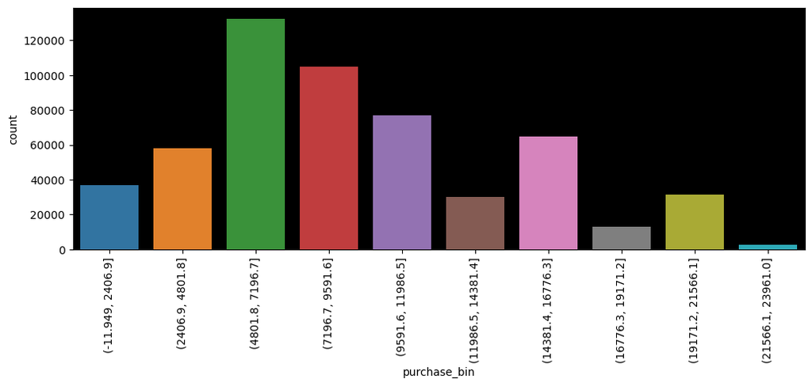

```python
plt.figure(figsize=(12,4))
df["purchase_bin"]=pd.cut(df["Purchase"],bins=10)
sns.countplot(data=df,x="purchase_bin")
plt.xticks(rotation=90)
ax=plt.gca()
ax.set_facecolor('black')
plt.show()
```

Business Insights: The graph illustrates the distribution of purchase amounts across product categories. It reveals that the highest concentration of purchases falls within the range of 4,801 to 7,196, indicating that customers within this range exhibit significant potential for making purchases. Conversely, the lowest purchase range, from 21,566 to 23,961, has the fewest number of transactions, suggesting that customers are less likely to make purchases within this price bracket.

### Top userID with maximum number of purchases

```python
df.groupby(by=['User_ID'])['Purchase'].count().sort_values(ascending=False)[:10].reset_index()
```

|  | User_ID | Purchase |
| --- | --- | --- |
| 0 | 1001680 | 1026 |
| 1 | 1004277 | 979 |
| 2 | 1001941 | 898 |
| 3 | 1001181 | 862 |
| 4 | 1000889 | 823 |
| 5 | 1003618 | 767 |
| 6 | 1001150 | 752 |
| 7 | 1001015 | 740 |
| 8 | 1005795 | 729 |
| 9 | 1005831 | 727 |

Statement: In this dataset, we observe user IDs and their corresponding purchase values. User 1001680 made the highest purchase at 1026, suggesting strong engagement. However, User 1004277, despite being second, has a lower purchase value (979), indicating potential for increased spending. Users 1001941, 1001181, and 1000889 also exhibit significant purchases, warranting attention for retention and upselling efforts. Monitoring and analyzing these user behaviors can lead to improved revenue growth strategies.

### Occupation category having the contribution in Purchase

```python
occcupation = pd.DataFrame(df.groupby(by=['Occupation'])['Purchase'].sum())
occcupation['percentage']  = occcupation['Purchase']/occcupation['Purchase'].sum()*100
occcupation
```

| Occupation | Purchase | percentage |
| --- | --- | --- |
| 0 | 635406958 | 12.469198 |
| 1 | 424614144 | 8.332609 |
| 2 | 238028583 | 4.671062 |
| 3 | 162002168 | 3.179123 |
| 4 | 666244484 | 13.074352 |
| 5 | 113649759 | 2.230258 |
| 6 | 188416784 | 3.697482 |
| 7 | 557371587 | 10.937835 |
| 8 | 14737388 | 0.289206 |
| 9 | 54340046 | 1.066367 |
| 10 | 115844465 | 2.273327 |
| 11 | 106751618 | 2.094889 |
| 12 | 305449446 | 5.994126 |
| 13 | 71919481 | 1.411345 |
| 14 | 259454692 | 5.091527 |
| 15 | 118960211 | 2.334470 |
| 16 | 238346955 | 4.677310 |
| 17 | 393281453 | 7.717738 |
| 18 | 60721461 | 1.191595 |
| 19 | 73700617 | 1.446298 |
| 20 | 296570442 | 5.819885 |

Statement: This dataset presents purchase amounts and their respective percentages for different occupation categories. Notably, occupations 0, 4, and 7 contribute significantly to the total purchases, accounting for approximately 36% of the total. Occupations 8, 9, 13, and 18 make smaller contributions, suggesting potential growth opportunities through targeted marketing efforts. Occupations 2, 3, 5, and 19 have relatively lower percentages, indicating room for improvement in engaging these segments to increase their contribution to overall sales.

### Optimising the max sales of product

```python
datasales = df.groupby(by=['Product_ID'])['Purchase'].count().sort_values(ascending=False)[:10]
datasales
```

```
Product_ID
P00265242    1880
P00025442    1615
P00110742    1612
P00112142    1562
P00057642    1470
P00184942    1440
P00046742    1438
P00058042    1422
P00145042    1406
P00059442    1406
Name: Purchase, dtype: int64
```

Statement: This dataset provides the sales quantities for different product IDs. Product P00265242 is the top seller with 1880 units sold, followed by P00025442 and P00110742 at 1615 and 1612 units, respectively. These insights highlight the best-performing products, which could be prioritized for marketing and inventory management. Additionally, it's important to investigate the characteristics of these top-selling products to identify customer preferences and potentially replicate their success with similar items.

### Contributing the product category with purchase

```python
pdp = pd.DataFrame(df.groupby(by=['Product_Category'])['Purchase'].sum())
pdp['percentage'] = pdp['Purchase']/pdp['Purchase'].sum()*100
pdp
```

| Product_Category | Purchase | percentage |
| --- | --- | --- |
| 1 | 1910013754 | 37.482024 |
| 2 | 268516186 | 5.269350 |
| 3 | 204084713 | 4.004949 |
| 4 | 27380488 | 0.537313 |
| 5 | 941835229 | 18.482532 |
| 6 | 324150302 | 6.361111 |
| 7 | 60896731 | 1.195035 |
| 8 | 854318799 | 16.765114 |
| 9 | 6370324 | 0.125011 |
| 10 | 100837301 | 1.978827 |
| 11 | 113791115 | 2.233032 |
| 12 | 5331844 | 0.104632 |
| 13 | 4008601 | 0.078665 |
| 14 | 20014696 | 0.392767 |
| 15 | 92969042 | 1.824420 |
| 16 | 145120612 | 2.847840 |
| 17 | 5878699 | 0.115363 |
| 18 | 9290201 | 0.182310 |
| 19 | 59378 | 0.001165 |
| 20 | 944727 | 0.018539 |

Statement: This dataset displays purchase amounts and their corresponding percentages for various product categories. Product category 1 dominates with 37.48% of total purchases, indicating its high popularity among customers. Categories 5 and 8 also make substantial contributions at 18.48% and 16.77%, respectively. Conversely, categories 4, 9, 12, and 13 have minimal shares, suggesting potential areas for growth or optimization in the product catalog.

```python
df[:1]
```

|  | User_ID | Product_ID | Gender | Age | Occupation | City_Category | Stay_In_Current_City_Years | Marital_Status | Product_Category | Purchase |
| --- | --- | --- | --- | --- | --- | --- | --- | --- | --- | --- |
| 0 | 1000001 | P00069042 | F | 0-17 | 10 | A | 2 | 0 | 3 | 8370 |

```python
stc = pd.DataFrame(df.groupby(by=['Stay_In_Current_City_Years'])['Purchase'].sum())
stc['percentage'] = stc['Purchase']/stc['Purchase'].sum()*100
stc
```

| Stay_In_Current_City_Years | Purchase | percentage |
| --- | --- | --- |
| 0 | 682979229 | 13.402754 |
| 1 | 1792872533 | 35.183250 |
| 2 | 949173931 | 18.626547 |
| 3 | 884902659 | 17.365290 |
| 4+ | 785884390 | 15.422160 |

```python
df.groupby(by=['City_Category'])['Marital_Status'].count()
```

```
City_Category
A    147720
B    231173
C    171175
Name: Marital_Status, dtype: int64
```

### Contributing Marriage status towards in Cities

```python
pd.crosstab(index=df['City_Category'], columns=df['Marital_Status'],normalize=True)
```

| Marital_Status City_Category | 0 | 1 |
| --- | --- | --- |
| A | 0.165749 | 0.102800 |
| B | 0.248553 | 0.171710 |
| C | 0.176046 | 0.135143 |

### Data Distribution among Purchase Range

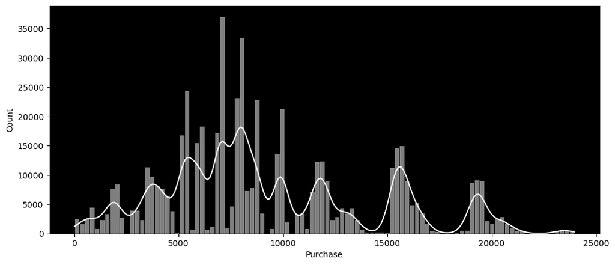

```python
plt.figure(figsize=(12,5))
sns.histplot(data=df, x='Purchase', bins=100, kde=True,color="white")
ax=plt.gca()
ax.set_facecolor('black')
plt.show()
```

Statement: The chart illustrates the distribution of product purchases within a predetermined budget range, typically ranging from 0 to approximately 23,000. Notably, the majority of purchases tend to cluster around the average range of approximately 9,000. This information is crucial for businesses to understand their customers' spending patterns and can guide pricing strategies and product offerings to align with these preferences and budget constraints.

### Outlier Detection || Contributing with Purchase

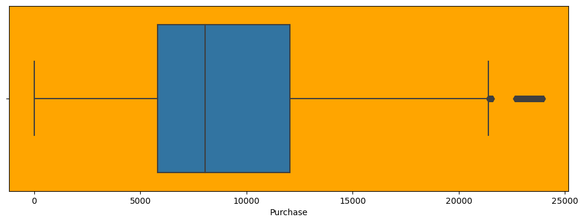

```python
plt.figure(figsize=(12,4))
sns.boxplot(data=df, x='Purchase')
ax=plt.gca()
ax.set_facecolor('orange')
plt.show()
```

Statement: The boxplot visualizes the distribution of purchase amounts within a predefined range, typically spanning from 0 to around 25,000 purchase amount. Notably, the plot indicates that only a small fraction of purchases falls above the 22,000 mark but below 25,000. These outliers suggest that a few customers are making exceptionally high-value purchases, which may warrant special attention in terms of customer engagement and targeted marketing strategies to capitalize on their substantial spending.

### Category of Product Analysis based on users

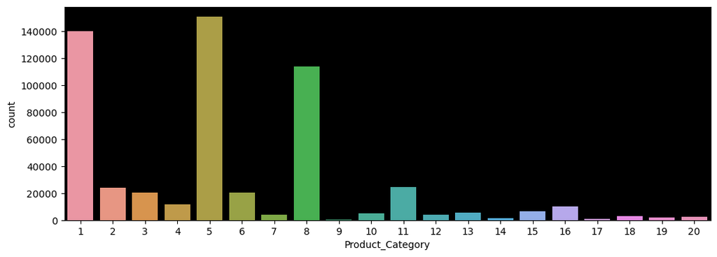

```python
plt.figure(figsize=(12,4))
sns.countplot(data=df, x='Product_Category')
ax=plt.gca()
ax.set_facecolor('black')
plt.show()
```

Statement: The graph indicates the most popular product categories among customers. Categories 1, 5, and 8 stand out as the highest-selling products, signifying their strong demand and profitability. Conversely, categories 2, 3, and 11 represent products with average sales. Businesses can focus resources on promoting and optimizing offerings within the top-performing categories to maximize revenue and customer satisfaction.

### Analysis towards Keys Factors

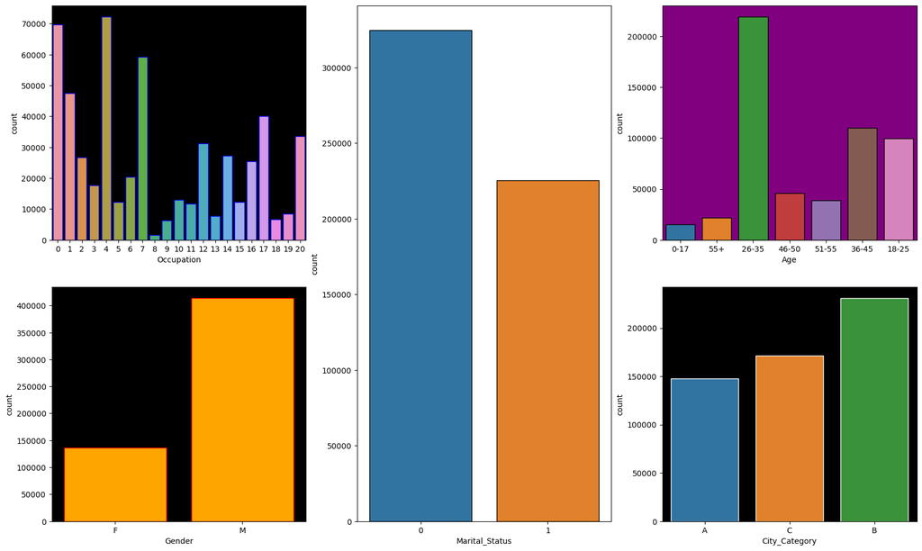

```python
plt.figure(figsize=(20,12))
plt.subplot(2,3,1)
sns.countplot(data=df, x='Occupation',ec='b')
ax=plt.gca()
ax.set_facecolor('black')
plt.subplot(2,3,3)
sns.countplot(data=df, x='Age', ec='k')
ax=plt.gca()
ax.set_facecolor('purple')
plt.subplot(2,3,4)
sns.countplot(data=df, x='Gender',ec='r', fc='orange')
ax=plt.gca()
ax.set_facecolor('black')
plt.subplot(2,3,6)
sns.countplot(data=df, x='City_Category',ec='w')
ax=plt.gca()
ax.set_facecolor('black')
plt.subplot(1,3,2)
sns.countplot(data=df, x='Marital_Status',ec='k')
ax=plt.gca()
ax.set_facecolor('white')
plt.show()
```

Insights: The set of graphs provides valuable insights into various customer segments:

1.Marital Status Impact: The data suggests that a larger portion of customers are categorized as "Single" (Marital Status 0) rather than "Engaged." Businesses may tailor their marketing strategies to target this single demographic effectively.

2.Age Influence: The most prominent age group contributing to product purchases and capacity lies between 26 and 35 years old. Understanding this can guide product development and marketing efforts toward this age group.

3.City Category Preferences: City Category "B" is the most populated, indicating that it's crucial for businesses to focus on serving the needs of customers residing in this category.

4.Gender-Based Trends: Males significantly contribute to product purchases compared to females. Recognizing this trend allows businesses to customize products and marketing strategies to cater to male customers effectively.

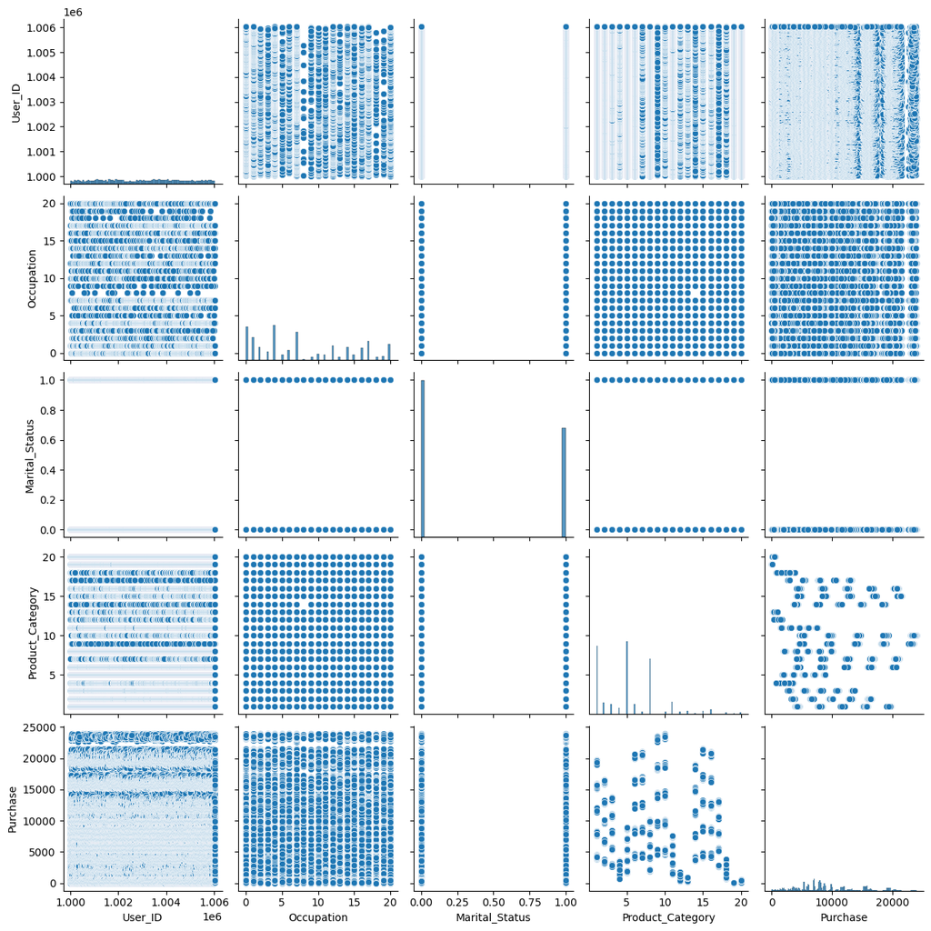

```python
sns.pairplot(df)
plt.show()
```

Insights:The provided graph displays a pair plot depicting the relationships between various categories. It is evident that each category appears to be self-contained and independent, with no discernible correlations or connections between them. This suggests that the columns representing these categories do not exhibit any meaningful interdependence in the context of our business analysis.

### Inference after computing the average female and male expenses.

```python
Avg_pur_gender = pd.DataFrame(df.groupby(by=['Gender'])['Purchase'].mean())
Avg_pur_gender["percentage"] = Avg_pur_gender['Purchase']/Avg_pur_gender['Purchase'].mean()*100
Avg_pur_gender
```

| Gender | Purchase | percentage |
| --- | --- | --- |
| F | 8734.565765 | 96.131649 |
| M | 9437.526040 | 103.868351 |

### inference after computing the total female and male expenses.

```python
total_pur_gender = pd.DataFrame(df.groupby(by=['Gender'])['Purchase'].sum())
total_pur_gender["percentage"] = total_pur_gender['Purchase']/total_pur_gender['Purchase'].sum()*100
total_pur_gender
```

| Gender | Purchase | percentage |
| --- | --- | --- |
| F | 1186232642 | 23.278576 |
| M | 3909580100 | 76.721424 |

Business Insights: The table provides a breakdown of purchase amounts and percentages by gender. Notably, male customers account for a substantial majority, contributing 76.72% of the total purchase value, while female customers account for 23.28%. This suggests that males have a more significant impact on overall sales. Businesses may consider tailoring their marketing strategies and product offerings to better target and engage male customers to maximize revenue and profitability.

### Inference Computing the average male expenses.

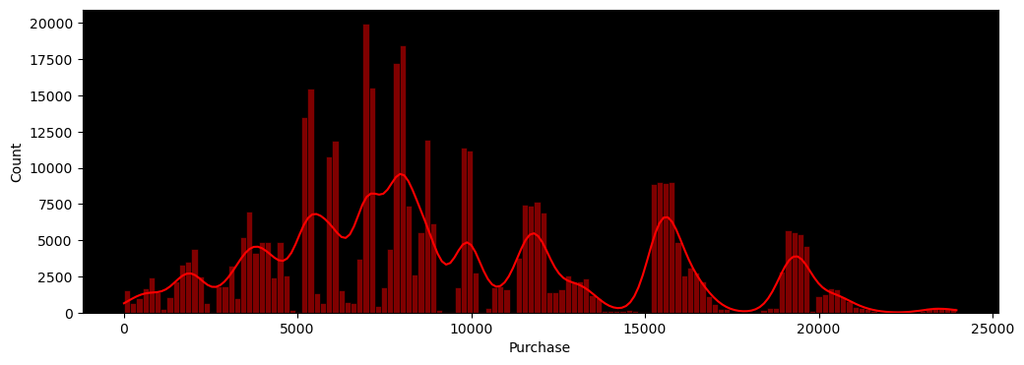

```python
plt.figure(figsize=(12,4))
male = df[df['Gender']=="M"]
sns.histplot(data=male, x='Purchase',kde=True,color="Red",bins="auto")
ax=plt.gca()
ax.set_facecolor('black')
plt.show()
```

### Inference Computing the average female expenses.

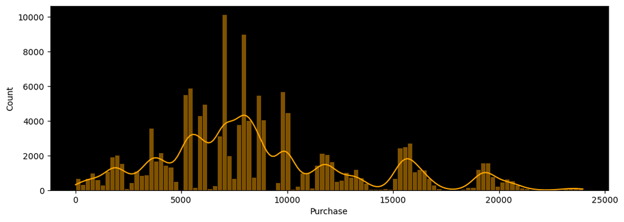

```python
plt.figure(figsize=(12,4))
female = df[df['Gender']=="F"]
sns.histplot(data=female, x='Purchase',kde=True,color="Orange")
ax=plt.gca()
ax.set_facecolor('black')
plt.show()
```

### showcasing correlation Among

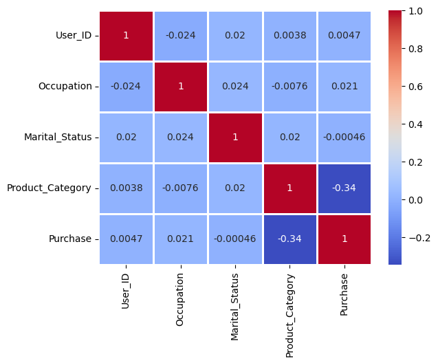

```python
sns.heatmap(data=df.corr(),annot=True,cmap='coolwarm', linewidths=1)
plt.show()
```

Insights: There appears to be a concerning lack of positive correlation between our products and various categorical and numerical variables. Typically, strong relationships are expected between products and user-related factors, but our data suggests that the product-to-product correlations are quite weak, often falling below the 0.7 threshold. Furthermore, we've observed negative correlations between product category and purchase behavior, as well as between user ID and occupation. These findings indicate potential challenges in optimizing product recommendations and understanding user preferences.

### Detecing outliers through all Segments with Purchase

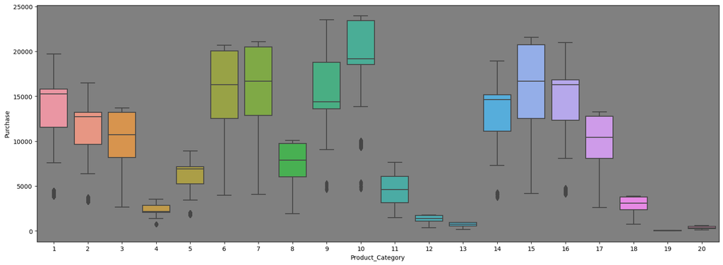

```python
plt.figure(figsize=(20,7))
sns.boxplot(data=df,x="Product_Category",y='Purchase')
ax=plt.gca()
ax.set_facecolor('grey')
plt.show()
```

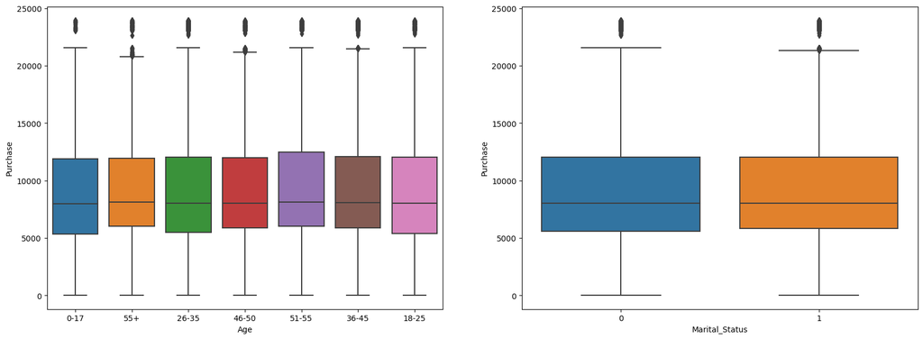

```python
plt.figure(figsize=(20,7))
plt.subplot(1,2,1)
sns.boxplot(data=df, x="Age",y="Purchase")
plt.subplot(1,2,2)
sns.boxplot(data=df, x="Marital_Status",y="Purchase")
plt.show()
```

Insights: The first boxplot illustrates how age impacts purchasing behavior, with noticeable variations and outliers. Notably, customers aged 55+, 46-50, and 36-45 exhibit significant outliers, suggesting complex spending patterns among older demographics. The second boxplot indicates relatively even distribution between categories 0 and 1, but outliers are more prevalent in category 1. This highlights potential opportunities for targeted strategies to engage customers in category 1 and explore underlying factors behind these outliers.

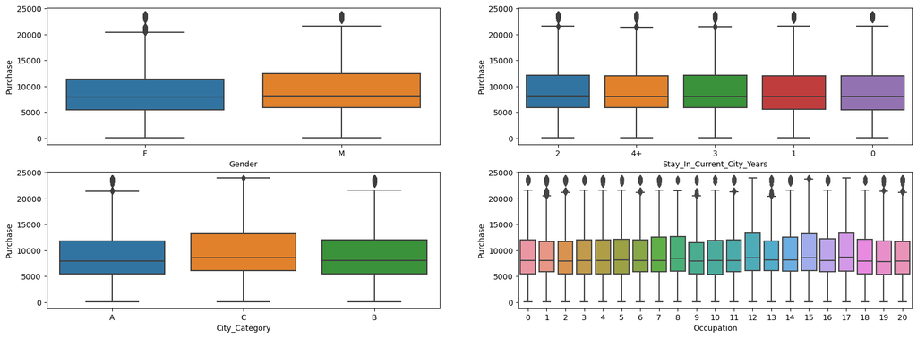

```python
plt.figure(figsize=(20,7))
plt.subplot(2,2,1)
sns.boxplot(data=df, x="Gender", y="Purchase")
plt.subplot(2,2,2)
sns.boxplot(data=df, x="Stay_In_Current_City_Years", y="Purchase")
plt.subplot(2,2,3)
sns.boxplot(data=df, x="City_Category", y="Purchase")
plt.subplot(2,2,4)
sns.boxplot(data=df, x="Occupation", y="Purchase")
plt.show()
```

Insights: The gender-based analysis of purchase behavior reveals distinct patterns. Males display a wider range of purchasing habits compared to females, with notable outliers among females. Interestingly, current city years exhibit a relatively uniform influence across all purchase categories. However, category C stands out with a broad range of purchases and minimal outliers compared to other categories. Occupations demonstrate consistent influence across all levels, implying that various segments within this dataset share similar purchasing tendencies. These insights emphasize the significance of gender and product category in understanding customer behavior for tailored marketing strategies.

### Multivariate Analaysis through the Gender and Purchase with Category

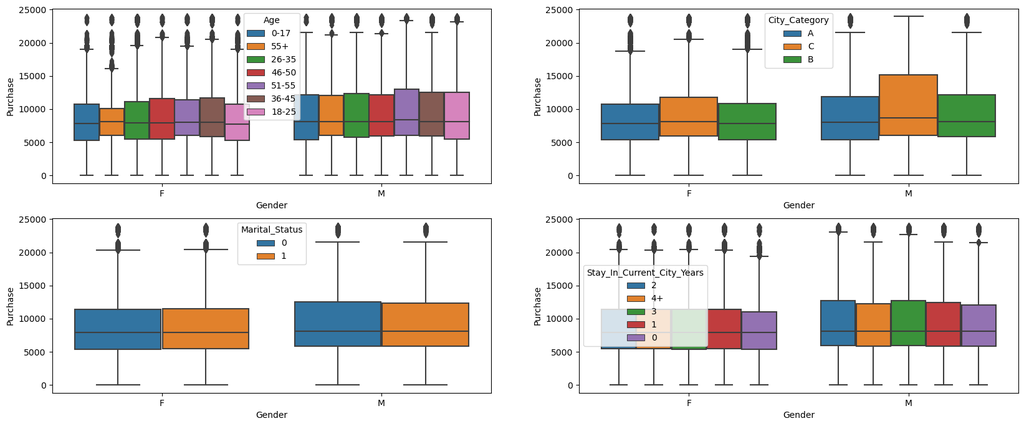

```python
plt.figure(figsize=(20,8))
plt.subplot(2,2,1)
sns.boxplot(data=df, x="Gender", y="Purchase", hue="Age")
plt.subplot(2,2,2)
sns.boxplot(data=df, x="Gender", y="Purchase", hue="City_Category")
plt.subplot(2,2,3)
sns.boxplot(data=df, x="Gender", y="Purchase", hue="Marital_Status")
plt.subplot(2,2,4)
sns.boxplot(data=df, x="Gender", y="Purchase", hue="Stay_In_Current_City_Years")
plt.show()
```

Insights: The boxplot pictorial represetation states that the major of the people who lies in age above 55+ well shown tendency a very shrink and small bunch of range fallsin female category, where as the female tends to have a high amount of urchase startegy where the outliers falls a big portion of it. The Male with the C city type tends to have a high portion of segmented values while female purchajsing powwrr is lower thsn male in all citiueds categories.

### Average Spending of Customers

```python
avgspent = df.groupby(by=['User_ID','Gender'])['Purchase'].sum()
avgspent = avgspent.reset_index()
avgspent
```

|  | User_ID | Gender | Purchase |
| --- | --- | --- | --- |
| 0 | 1000001 | F | 334093 |
| 1 | 1000002 | M | 810472 |
| 2 | 1000003 | M | 341635 |
| 3 | 1000004 | M | 206468 |
| 4 | 1000005 | M | 821001 |
| ... | ... | ... | ... |
| 5886 | 1006036 | F | 4116058 |
| 5887 | 1006037 | F | 1119538 |
| 5888 | 1006038 | F | 90034 |
| 5889 | 1006039 | F | 590319 |
| 5890 | 1006040 | M | 1653299 |

5891 rows × 3 columns

### Average number of Customers (Gender- Wise)

```python
avgspent['Gender'].value_counts()
```

```
M    4225
F    1666
Name: Gender, dtype: int64
```

Insights: Our customer data shows that there are 4,225 male customers and 1,666 female customers, highlighting a gender imbalance.

### Total Spent

```python
avgspent.groupby(by=['Gender'])['Purchase'].sum()
```

```
Gender
F    1186232642
M    3909580100
Name: Purchase, dtype: int64
```

Insights: Females account for a total purchase value of $1,186,232,642, while males have a higher total purchase value of $3,909,580,100.

### Average Spent

```python
avgspent.groupby(by=['Gender'])['Purchase'].mean()
```

```
Gender
F    712024.394958
M    925344.402367
Name: Purchase, dtype: float64
```

Insights: On average, males have higher purchase amounts at approximately $925,344, while females spend an average of about $712,024, indicating a gender-based spending disparity.

### Female Average spending

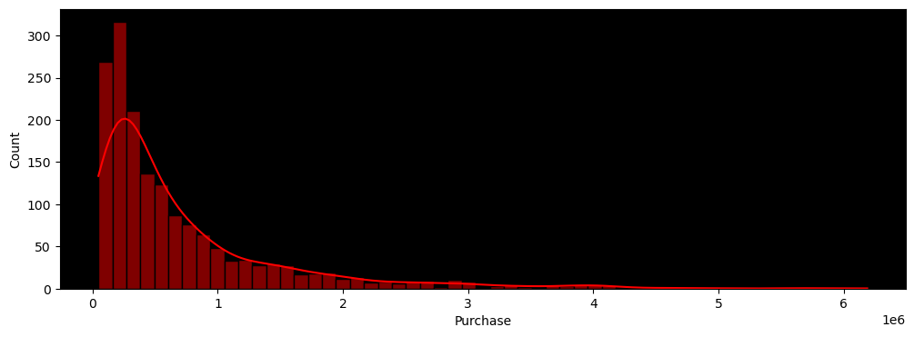

```python
plt.figure(figsize=(12,4))
sns.histplot(data=avgspent,x=avgspent[avgspent['Gender']=="F"]['Purchase'],kde=True,color="Red")
ax=plt.gca()
ax.set_facecolor('black')
plt.show()
```

### Male Average spending

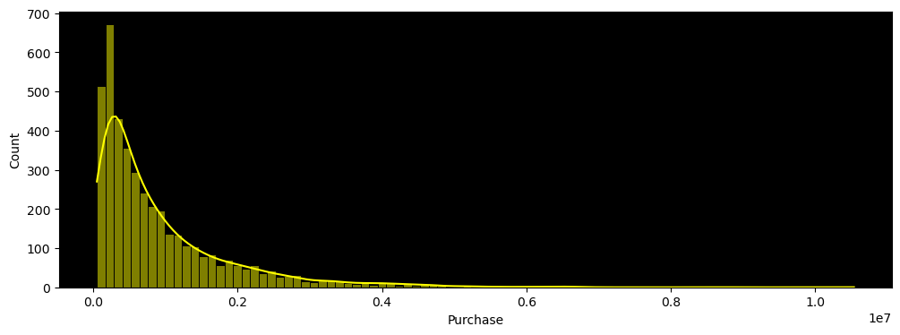

```python
plt.figure(figsize=(12,4))
sns.histplot(data=avgspent,x=avgspent[avgspent['Gender']=="M"]['Purchase'],kde=True,color="yellow")
ax=plt.gca()
ax.set_facecolor('black')
plt.show()
```

### Cities Contributing Purchase Power

```python
cities =df.groupby(by=['City_Category'])['Purchase'].sum().to_frame().reset_index()
cities['Average'] = cities['Purchase'].mean()
cities
```

|  | City_Category | Purchase | Average |
| --- | --- | --- | --- |
| 0 | A | 1316471661 | 1.698604e+09 |
| 1 | B | 2115533605 | 1.698604e+09 |
| 2 | C | 1663807476 | 1.698604e+09 |

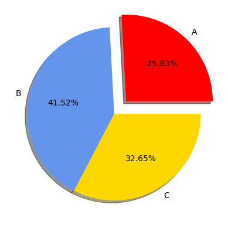

```python
from matplotlib.pyplot import pie, show
plt.pie(cities['Purchase'],autopct='%1.2f%%',labels=['A','B','C'],colors=['red',"cornflowerblue",'gold'],explode=[0.2,0,0],shadow=True)
show()
```

```python
avgspent
```

|  | User_ID | Gender | Purchase |
| --- | --- | --- | --- |
| 0 | 1000001 | F | 334093 |
| 1 | 1000002 | M | 810472 |
| 2 | 1000003 | M | 341635 |
| 3 | 1000004 | M | 206468 |
| 4 | 1000005 | M | 821001 |
| ... | ... | ... | ... |
| 5886 | 1006036 | F | 4116058 |
| 5887 | 1006037 | F | 1119538 |
| 5888 | 1006038 | F | 90034 |
| 5889 | 1006039 | F | 590319 |
| 5890 | 1006040 | M | 1653299 |

5891 rows × 3 columns

```python
avgspent_male = avgspent[avgspent['Gender']=='M']
avgspent_female = avgspent[avgspent['Gender']=='F']
```

### Finding the sample(sample size=1000) for avg purchase amount for males and females

```python
genders = ["M", "F"]

sample_size = 1000

samples_work_repeat = 1000
male_means = []
female_means = []

for i in range(samples_work_repeat):
    male_mean = avgspent_male.sample(sample_size, replace=True)['Purchase'].mean()
    female_mean = avgspent_female.sample(sample_size,replace=True)['Purchase'].mean()

    male_means.append(male_mean)
    female_means.append(female_mean)
```

```
<function matplotlib.pyplot.show(close=None, block=None)>
```

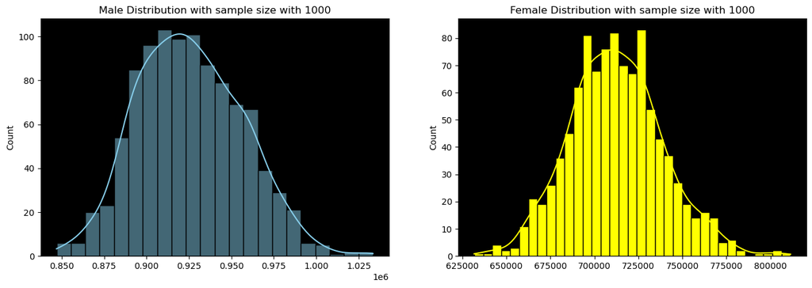

```python
plt.figure(figsize=(16,5))
plt.subplot(1,2,1)
sns.histplot(male_means,color="skyblue",ec="k",kde=True)
plt.title("Male Distribution with sample size with 1000")
ax=plt.gca()
ax.set_facecolor('black')
plt.subplot(1,2,2)
sns.histplot(female_means,bins=35,fc="yellow",ec='k',kde=True)
plt.title("Female Distribution with sample size with 1000")
ax=plt.gca()
ax.set_facecolor('black')
plt.show
```

Business Insights (Male): The histogram of male purchase means shows a relatively normal distribution. This suggests that, on average, male customers exhibit consistent spending patterns. Businesses can rely on this consistency to tailor marketing strategies and product offerings to meet the expectations of their male customer base.

### Finding the Samples with Purchases with CLT

```python
population_mean  = df['Purchase'].mean()
population_stddev = df['Purchase'].std()
population_size  = len(df['Purchase'])
num_samples = 1000
sample_size = 30
sample_means = []

for i in range(num_samples):
    # Generating a random sample from the population
    sample = np.random.normal(population_mean, population_stddev, sample_size)

    # Calculating the sample mean and add it to the list
    sample_mean = np.mean(sample)
    sample_means.append(sample_mean)
```

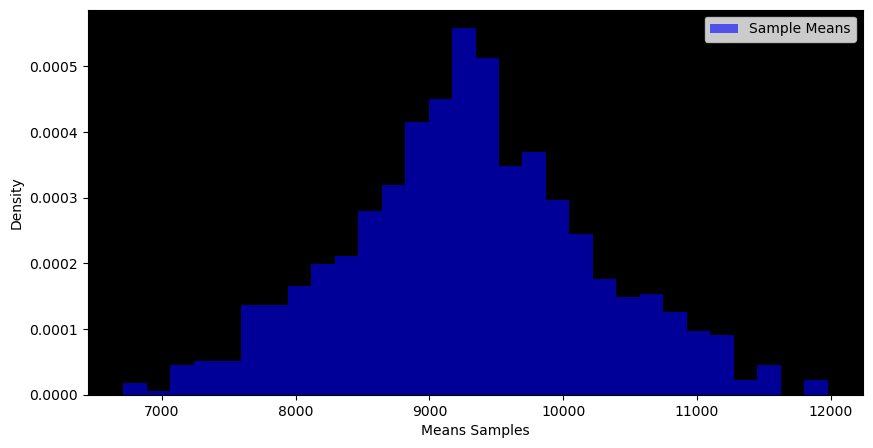

```python
plt.figure(figsize=(10,5))
plt.hist(sample_means, bins=30, density=True, alpha=0.6, color='b', label='Sample Means')
plt.legend()
ax=plt.gca()
plt.xlabel("Means Samples")
plt.ylabel("Density")
ax.set_facecolor('black')
plt.show()
```

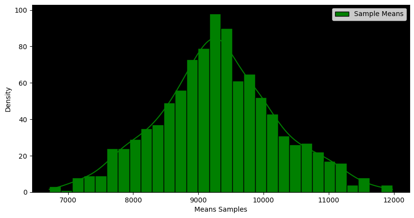

```python
plt.figure(figsize=(10,5))
sns.histplot(sample_means,kde=True,label="Sample Means",bins=30,fc='g')
plt.legend()
ax=plt.gca()
plt.xlabel("Means Samples")
plt.ylabel("Density")
ax.set_facecolor('black')
plt.show()
```

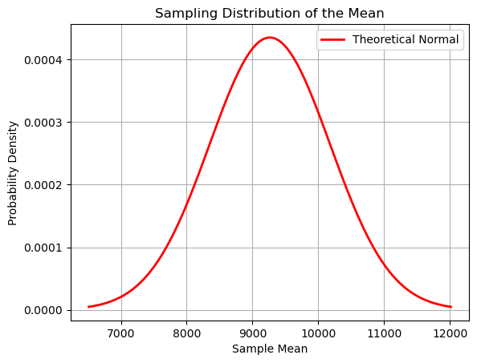

```python
sample_mean_theoretical = population_mean
sample_stddev_theoretical = population_stddev / np.sqrt(sample_size)
sample_stddev_theoretical
x = np.linspace(sample_mean_theoretical - 3*sample_stddev_theoretical,
                sample_mean_theoretical + 3*sample_stddev_theoretical, 100)
pdf = (1/(sample_stddev_theoretical * np.sqrt(2 * np.pi))) * \
      np.exp(-(x - sample_mean_theoretical)**2 / (2 * sample_stddev_theoretical**2))

# Plot the theoretical normal distribution
plt.plot(x, pdf, 'r', lw=2, label='Theoretical Normal')

plt.title('Sampling Distribution of the Mean')
plt.xlabel('Sample Mean')
plt.ylabel('Probability Density')
plt.legend()
plt.grid(True)

plt.show()
```

## Observation for Confidence Interval at 90%, 95%, 99% for MALE and FEMALE

### Observing at 90% Confidence Interval for Sample Size 1000 at z=90

#### population Average Mean

```python
print("Population Average Amount Spent for Male: {:.2f}".format(avgspent_male['Purchase'].mean()))
print("Population Average Amount Spent for Female: {:.2f}\n".format(avgspent_female['Purchase'].mean()))
```

```
Population Average Amount Spent for Male: 925344.40
Population Average Amount Spent for Female: 712024.39
```

#### Sample Average Mean

```python
print("Sample Average Amount spent for Male: {:.2f}".format(np.mean(male_means)))
print("Sample Average Amount spent for Female: {:.2f}\n".format(np.mean(female_means)))
```

```
Sample Average Amount spent for Male: 925827.52
Sample Average Amount spent for Female: 712358.43
```

#### Sample Standard Deviation

```python
print("The std dev for Sample for Male: {:.2f}".format(pd.Series(male_means).std()))
print("The std dev for Sample for Female: {:.2f}".format(pd.Series(female_means).std()))
```

```
The std dev for Sample for Male: 30762.23
The std dev for Sample for Female: 26403.44
```

#### Sample Error (Std()/sqrt(n))

```python
print("Sample Standard Error for Male: {:.2f}".format(pd.Series(male_means).std()/np.sqrt(1000)))
print("Sample Standard Error for Female: {:.2f}\n".format(pd.Series(female_means).std()/np.sqrt(1000)))
```

```
Sample Standard Error for Male: 972.79
Sample Standard Error for Female: 834.95
```

```python
sample_mean_male=np.mean(male_means)
sample_mean_female=np.mean(female_means)

sample_std_male=pd.Series(male_means).std()
sample_std_female=pd.Series(female_means).std()

sample_std_error_male=sample_std_male/np.sqrt(1000)
sample_std_error_female=sample_std_female/np.sqrt(1000)
```

```python
#Calculating Confidence Interval with Formula: (mu(sample)+z*std),(mu(sample)-z*std) at 90% confidence level
```

```python
z90 = 1.645
First_scale_male_z90=z90*sample_std_error_male + sample_mean_male
last_scale_male_z90=sample_mean_male - z90*sample_std_error_male

first_scale_female_z90=z90*sample_std_error_female + sample_mean_female
last_scale_female_z90=sample_mean_female - z90*sample_std_error_female
```

### Confidence Interval at 90%

```python
print("Male_Confidence_interval_z90: ",[First_scale_male,last_scale_male])
print("Female_Confidence_intervalz90: ",[first_scale_female,last_scale_female])
```

[output not shown]

### Observing at 95% Confidence Interval for Sample Size 1000 at z=95

```python
sample_mean_male=np.mean(male_means)
sample_mean_female=np.mean(female_means)

sample_std_male=pd.Series(male_means).std()
sample_std_female=pd.Series(female_means).std()

sample_std_error_male=sample_std_male/np.sqrt(1000)
sample_std_error_female=sample_std_female/np.sqrt(1000)
```

```python
# Calculating Confidence Interval with Formula: (mu(sample)+z*std),(mu(sample)-z*std) at 95% confidence level
```

```python
z95 = 1.96
First_scale_male95=z95*sample_std_error_male + sample_mean_male
last_scale_male95=sample_mean_male - z95*sample_std_error_male

first_scale_female95=z95*sample_std_error_female + sample_mean_female
last_scale_female95=sample_mean_female - z95*sample_std_error_female
```

### Confidence Interval at 95%

```python
print("Male_Confidence_interval: ",[First_scale_male95,last_scale_male95])
print("Female_Confidence_interval: ",[first_scale_female95,last_scale_female95])
```

[output not shown]

## Observing at 99% Confidence Interval for Sample Size 1000 at z=99

```python
sample_mean_male=np.mean(male_means)
sample_mean_female=np.mean(female_means)

sample_std_male=pd.Series(male_means).std()
sample_std_female=pd.Series(female_means).std()

sample_std_error_male=sample_std_male/np.sqrt(1000)
sample_std_error_female=sample_std_female/np.sqrt(1000)
```

```python
# Calculating Confidence Interval with Formula: (mu(sample)+z*std),(mu(sample)-z*std) at 99% confidence level
```

```python
z99 = 2.576
First_scale_male99=z99*sample_std_error_male + sample_mean_male
last_scale_male99=sample_mean_male - z99*sample_std_error_male

first_scale_female99=z99*sample_std_error_female + sample_mean_female
last_scale_female99=sample_mean_female - z99*sample_std_error_female
```

### Confidence Interval at 99%

```python
print("Male_Confidence_interval: ",[First_scale_male99,last_scale_male99])
print("Female_Confidence_interval: ",[first_scale_female99,last_scale_female99])
```

```
Male_Confidence_interval:  [927935.3437719333, 922645.1489980666]
Female_Confidence_interval:  [713244.160610302, 708917.2181876978]
```

Insights: Male Population Insight (99% Confidence): The 99% confidence interval for males 922,645.15, 927,935.34], indicates that we are highly confident in the estimated parameter's range. Businesses targeting males can make strategic decisions with a strong level of assurance regarding marketing, product development, and resource allocation.

Female Population Insight (99% Confidence): For females, the 99% confidence interval 708,917.22, 713,244.16 provides a robust basis for decision-making. Businesses focusing on females can rely on this interval for strategic planning, customer engagement, and market positioning with a high degree of confidence.

```python
df.head()
```

|  | User_ID | Product_ID | Gender | Age | Occupation | City_Category | Stay_In_Current_City_Years | Marital_Status | Product_Category | Purchase |
| --- | --- | --- | --- | --- | --- | --- | --- | --- | --- | --- |
| 0 | 1000001 | P00069042 | F | 0-17 | 10 | A | 2 | 0 | 3 | 8370 |
| 1 | 1000001 | P00248942 | F | 0-17 | 10 | A | 2 | 0 | 1 | 15200 |
| 2 | 1000001 | P00087842 | F | 0-17 | 10 | A | 2 | 0 | 12 | 1422 |
| 3 | 1000001 | P00085442 | F | 0-17 | 10 | A | 2 | 0 | 12 | 1057 |
| 4 | 1000002 | P00285442 | M | 55+ | 16 | C | 4+ | 0 | 8 | 7969 |

## CLT AND CONFIDENCE INTERVAL FOR MARITAL STATUS:

```python
avg_marital = df.groupby(['User_ID','Marital_Status'])['Purchase'].sum()
avg_marital = avg_marital.reset_index()
avg_marital.head()
```

|  | User_ID | Marital_Status | Purchase |
| --- | --- | --- | --- |
| 0 | 1000001 | 0 | 334093 |
| 1 | 1000002 | 0 | 810472 |
| 2 | 1000003 | 0 | 341635 |
| 3 | 1000004 | 1 | 206468 |
| 4 | 1000005 | 1 | 821001 |

```python
avg_married =avg_marital[avg_marital['Marital_Status']==1]
avg_unmarried =avg_marital[avg_marital['Marital_Status']==0]
```

```python
print(avg_married)
print(avg_unmarried)
```

```
      User_ID  Marital_Status  Purchase
3     1000004               1    206468
4     1000005               1    821001
6     1000007               1    234668
7     1000008               1    796593
9     1000010               1   2169510
...       ...             ...       ...
5879  1006029               1    157436
5880  1006030               1    737361
5883  1006033               1    501843
5886  1006036               1   4116058
5889  1006039               1    590319

[2474 rows x 3 columns]
      User_ID  Marital_Status  Purchase
0     1000001               0    334093
1     1000002               0    810472
2     1000003               0    341635
5     1000006               0    379930
8     1000009               0    594099
...       ...             ...       ...
5884  1006034               0    197086
5885  1006035               0    956645
5887  1006037               0   1119538
5888  1006038               0     90034
5890  1006040               0   1653299

[3417 rows x 3 columns]
```

### average expenses of customer depending upon their marital status

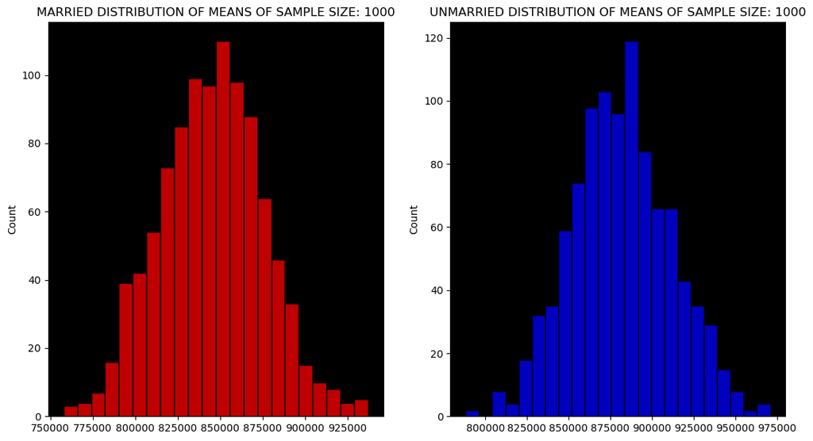

```python
sample_size = 1000
num_repitions = 1000

married_means = []
unmarried_means = []

for i in range(num_repitions):
    avg_married = avg_marital[avg_marital['Marital_Status']==1].sample(sample_size, replace=True)['Purchase'].mean()
    avg_unmarried = avg_marital[avg_marital['Marital_Status']==0].sample(sample_size, replace=True)['Purchase'].mean()

    married_means.append(avg_married)
    unmarried_means.append(avg_unmarried)


plt.figure(figsize =(13,7))
plt.subplot(1,2,1)
sns.histplot(married_means, bins='auto',color = 'red')
plt.title("MARRIED DISTRIBUTION OF MEANS OF SAMPLE SIZE: 1000")
ax=plt.gca()
ax.set_facecolor('black')


plt.subplot(1,2,2)
sns.histplot(unmarried_means, bins='auto',color='blue')
plt.title("UNMARRIED DISTRIBUTION OF MEANS OF SAMPLE SIZE: 1000")
ax=plt.gca()
ax.set_facecolor('black')

plt.show()
```

Insights: From the analysis, it is evident that the samples exhibit a normal distribution for both married and Unmarried customers. Additionally, we can glean valuable business insights by noting that the means of these sample sets closely align with the population mean, as stipulated by the central limit theorem. This suggests that our data is statistically reliable, enabling us to make more confident decisions based on this information.

```python
avg_marital['Marital_Status'].value_counts()
```

```
0    3417
1    2474
Name: Marital_Status, dtype: int64
```

This analysis reveals a noteworthy business insight: the unique count of occurrences for unmarried customers is significantly higher, standing at approximately 3417, as opposed to Unmarried, where the count is 2474 as Married. This disparity underscores the importance of catering to the needs and preferences of unmarried customers, as they constitute a larger portion of our target demographic.

### CALCULATING 90 % CONFIDENCE INTERVAL FOR AVERAGE EXPENSES FOR THE MARRIED AND UNMARRIED HAVING 1000 SAMPLE SIZE

#### At 90 % confidence Interval

```python
#Calculating Confidence Interval with Formula: (mu(sample)+z*std),(mu(sample)-z*std) at 90% confidence level
```

```python
z90 = norm.ppf((1 + 0.90)/2)
z90 = z90.round(3)
z90
```

```
1.645
```

```python
sample_mean_married=np.mean(married_means)
sample_mean_unmarried=np.mean(unmarried_means)
print(sample_mean_married)
print(sample_mean_unmarried)
```

```
845126.611096
881612.4409859999
```

```python
sample_std_married=pd.Series(married_means).std()
sample_std_unmarried=pd.Series(unmarried_means).std()
print(sample_std_married)
print(sample_std_unmarried)
```

```
30315.62730099818
29837.110649661743
```

```python
sample_std_error_married=sample_std_married/np.sqrt(1000)
sample_std_error_unmarried=sample_std_unmarried/np.sqrt(1000)
print(sample_std_error_married)
print(sample_std_error_unmarried)
```

```
958.6643096793717
943.5322845139738
```

#### calculate confidence interrval using formula CI = mean(sample) + (z(confidence percentage) * sample standard error)

```python
Upper_Limit_married = (sample_mean_married + (z90 * (sample_std_error_married)))
Lower_Limit_married = (sample_mean_married - (z90 * (sample_std_error_married)))
```

```python
Upper_Limit_unmarried = (sample_mean_unmarried + (z90 * (sample_std_error_unmarried)))
Lower_Limit_unmarried = (sample_mean_unmarried - (z90 * (sample_std_error_unmarried)))
```

```python
print("Married_CI: ",[Lower_Limit_married,Upper_Limit_married])
print("unmarried_CI: ",[Lower_Limit_unmarried,Upper_Limit_unmarried])
```

```
Married_CI:  [843549.6083065774, 846703.6138854225]
unmarried_CI:  [880060.3303779744, 883164.5515940253]
```

#### **CALCULATING 95 % CONFIDENCE INTERVAL FOR AVERAGE EXPENSES FOR THE MARRIED AND UNMARRIED HAVING 1000 SAMPLE SIZE**

##### At 95 % confidence Interval

```python
z95 = norm.ppf((1 + 0.95)/2)
z95 = z95.round(3)
z95
```

```
1.96
```

#### calculate confidence interrval using formula CI = mean(sample) + (z(confidence percentage) * sample standard error)

```python
Upper_Limit_married = (sample_mean_married + (z95 * (sample_std_error_married)))
Lower_Limit_married = (sample_mean_married - (z95 * (sample_std_error_married)))
```

```python
Upper_Limit_unmarried = (sample_mean_unmarried + (z95 * (sample_std_error_unmarried)))
Lower_Limit_unmarried = (sample_mean_unmarried - (z95 * (sample_std_error_unmarried)))
```

```python
print("Married_CI: ",[Lower_Limit_married,Upper_Limit_married])
print("Unmarried_CI: ",[Lower_Limit_unmarried,Upper_Limit_unmarried])
```

```
Married_CI:  [843247.6290490284, 847005.5931429715]
Unmarried_CI:  [879763.1177083525, 883461.7642636473]
```

### **CALCULATING 99 % CONFIDENCE INTERVAL FOR AVERAGE EXPENSES FOR THE MARRIED AND UNMARRIED HAVING 1000 SAMPLE SIZE**

#### # At 99 % confidence Interval

```python
z99 = norm.ppf((1 + 0.99)/2)
z99 = z99.round(3)
z99
```

```
2.576
```

#### calculate confidence interrval using formula CI = mean(sample) + (z(confidence percentage) * sample standard error)

```python
Upper_Limit_married = (sample_mean_married + (z99 * (sample_std_error_married)))
Lower_Limit_married = (sample_mean_married - (z99 * (sample_std_error_married)))
```

```python
Upper_Limit_unmarried = (sample_mean_unmarried + (z99 * (sample_std_error_unmarried)))
Lower_Limit_unmarried = (sample_mean_unmarried - (z99 * (sample_std_error_unmarried)))
```

```python
print("Married_CI: ",[Lower_Limit_married,Upper_Limit_married])
print("Unmarried_CI: ",[Lower_Limit_unmarried,Upper_Limit_unmarried])
```

```
Married_CI:  [842657.0918342659, 847596.130357734]
Unmarried_CI:  [879181.9018210919, 884042.9801509079]
```

### Calculating the CLT and CI for the Age groups with the purchase mean

```python
avg_age = df.groupby(['User_ID', 'Age'])[['Purchase']].sum()
avg_age = avgamt_age.reset_index()

avg_age = avg_age['Age'].value_counts()
avg_age=pd.DataFrame(avg_age).reset_index()
avg_age.rename(columns={"index":"Age_group","Age":"Counts"}, inplace=True)
```

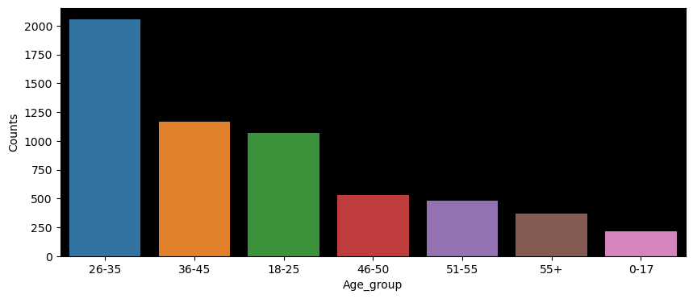

```python
plt.figure(figsize =(10,4))
sns.barplot(data=avg_age, x=avg_age['Age_group'],y=avg_age['Counts'])
ax=plt.gca()
ax.set_facecolor('black')
plt.show()
```

```python
sample_size = 500
num_repitions = 1000

all_sample_means = {}

age_intervals = ['26-35', '36-45', '18-25', '46-50', '51-55', '55+', '0-17']
for i in age_intervals:
    all_sample_means[i] = []

for i in age_intervals:
    for j in range(num_repitions):

        mean = avgamt_age[avgamt_age['Age']==i].sample(sample_size, replace=True)['Purchase'].mean()
        all_sample_means[i].append(mean)
```

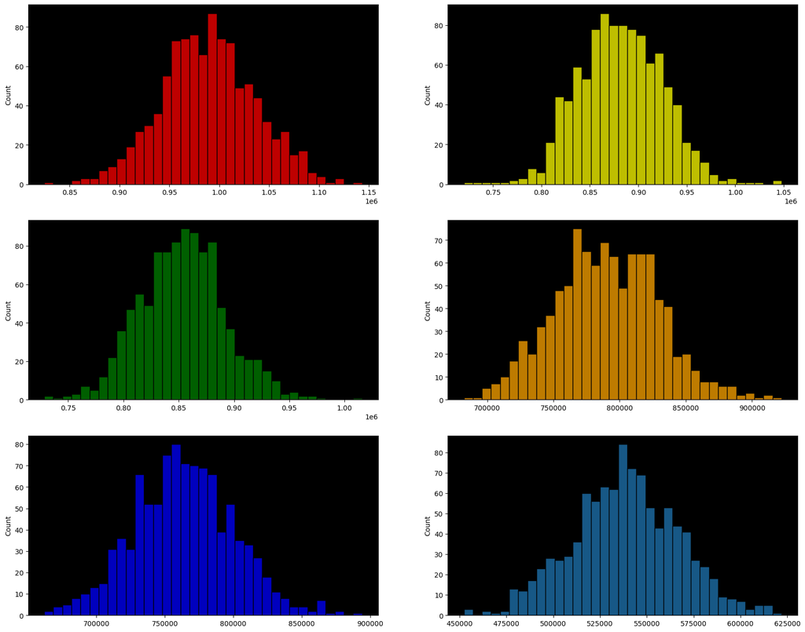

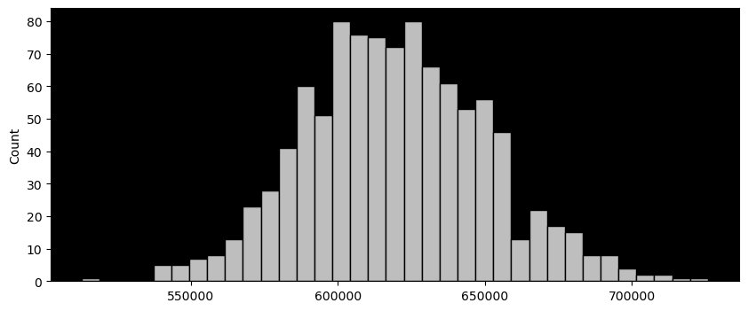

```python
plt.figure(figsize=(20,16))
plt.subplot(3,2,1)
sns.histplot(all_sample_means['26-35'],bins=35,color='red')
ax=plt.gca()
ax.set_facecolor('black')
plt.subplot(3,2,2)
sns.histplot(all_sample_means['36-45'],bins=35,color='yellow')
ax=plt.gca()
ax.set_facecolor('black')
plt.subplot(3,2,3)
sns.histplot(all_sample_means['18-25'],bins=35,color='green')
ax=plt.gca()
ax.set_facecolor('black')
plt.subplot(3,2,4)
sns.histplot(all_sample_means['46-50'],bins=35,color='orange')
ax=plt.gca()
ax.set_facecolor('black')
plt.subplot(3,2,5)
sns.histplot(all_sample_means['51-55'],bins=35,color='Blue')
ax=plt.gca()
ax.set_facecolor('black')
plt.subplot(3,2,6)
sns.histplot(all_sample_means['55+'],bins=35)
ax=plt.gca()
ax.set_facecolor('black')

plt.show()

plt.figure(figsize=(10, 4))
sns.histplot(all_sample_means['0-17'],bins=35,color='white')
ax=plt.gca()
ax.set_facecolor('black')
plt.show()
```

Insights: The analysis segments customers into distinct age intervals, such as '26-35', '36-45', '18-25', '46-50', '51-55', '55+', and '0-17'. This segmentation allows for a more granular understanding of purchasing behavior across various age groups.

Business Inisghts: The analysis indicates that the sample means exhibit a normal distribution pattern across all age groups. Additionally, a noteworthy business insight derived from this analysis is that the means of these samples closely approximate the population mean, aligning with the expectations of the central limit theorem. This suggests that our collected data is statistically reliable and can serve as a solid foundation for making informed business decisions related to customer purchasing behavior across different age groups.

```python
df.head()
```

|  | User_ID | Product_ID | Gender | Age | Occupation | City_Category | Stay_In_Current_City_Years | Marital_Status | Product_Category | Purchase |
| --- | --- | --- | --- | --- | --- | --- | --- | --- | --- | --- |
| 0 | 1000001 | P00069042 | F | 0-17 | 10 | A | 2 | 0 | 3 | 8370 |
| 1 | 1000001 | P00248942 | F | 0-17 | 10 | A | 2 | 0 | 1 | 15200 |
| 2 | 1000001 | P00087842 | F | 0-17 | 10 | A | 2 | 0 | 12 | 1422 |
| 3 | 1000001 | P00085442 | F | 0-17 | 10 | A | 2 | 0 | 12 | 1057 |
| 4 | 1000002 | P00285442 | M | 55+ | 16 | C | 4+ | 0 | 8 | 7969 |

```python
df.groupby(df["Age"])['Purchase'].describe()
```

| Age | count | mean | std | min | 25% | 50% | 75% | max |
| --- | --- | --- | --- | --- | --- | --- | --- | --- |
| 0-17 | 15102.0 | 8933.464640 | 5111.114046 | 12.0 | 5328.0 | 7986.0 | 11874.0 | 23955.0 |
| 18-25 | 99660.0 | 9169.663606 | 5034.321997 | 12.0 | 5415.0 | 8027.0 | 12028.0 | 23958.0 |
| 26-35 | 219587.0 | 9252.690633 | 5010.527303 | 12.0 | 5475.0 | 8030.0 | 12047.0 | 23961.0 |
| 36-45 | 110013.0 | 9331.350695 | 5022.923879 | 12.0 | 5876.0 | 8061.0 | 12107.0 | 23960.0 |
| 46-50 | 45701.0 | 9208.625697 | 4967.216367 | 12.0 | 5888.0 | 8036.0 | 11997.0 | 23960.0 |
| 51-55 | 38501.0 | 9534.808031 | 5087.368080 | 12.0 | 6017.0 | 8130.0 | 12462.0 | 23960.0 |
| 55+ | 21504.0 | 9336.280459 | 5011.493996 | 12.0 | 6018.0 | 8105.5 | 11932.0 | 23960.0 |

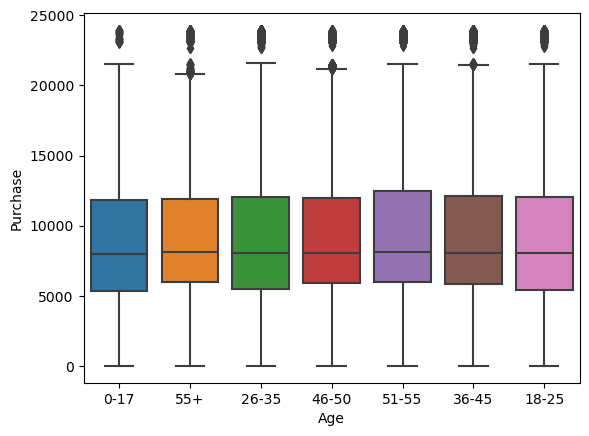

```python
sns.boxplot(data=df, x=df['Age'], y=df['Purchase'])
plt.show()
```

```python
ages = df.groupby(df["Age"])['Purchase'].mean()
ages = ages.reset_index()
ages
```

|  | Age | Purchase |
| --- | --- | --- |
| 0 | 0-17 | 8933.464640 |
| 1 | 18-25 | 9169.663606 |
| 2 | 26-35 | 9252.690633 |
| 3 | 36-45 | 9331.350695 |
| 4 | 46-50 | 9208.625697 |
| 5 | 51-55 | 9534.808031 |
| 6 | 55+ | 9336.280459 |

```python
ages["Age"][0]
```

```
'0-17'
```

```python
# male_sample_means= [df[df['Gender']=='M'].sample(300, replace=True)['Purchase'].mean() for i in range(1000)]
```

```python
ages_mean_sample17 = [ages[ages['Age']=="0-17"].sample(300, replace=True)['Purchase'].mean() for i in range(1000)]
ages_mean_sample17
```

[output not shown]

[output cut: 945 more lines]

[output not shown]

```python
np.mean(ages_mean_sample17)
```

```
8933.464640444976
```

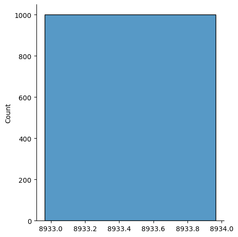

```python
sns.displot(ages_mean_sample17)
```

```python
ages_samples = [ages.sample(300, replace=True)['Purchase'].mean() for i in range(1000)]
ages_samples
```

[output not shown]

[output cut: 945 more lines]

[output not shown]

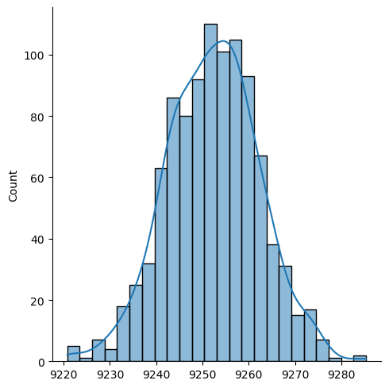

```python
sns.displot(ages_samples,kde=True)
plt.show()
```

```python
# ages_mean_sample17
```

```python
# Z-xcore at interval 95% is 1.96
```

```python
upper_limit_17 = np.mean(ages_mean_sample17) + 1.96*(np.std(ages_mean_sample17)/np.sqrt(300))
lower_limit_17 = np.mean(ages_mean_sample17) - 1.96*(np.std(ages_mean_sample17)/np.sqrt(300))
```

```python
upper_limit_17,lower_limit_17
```

```
(8933.464640444976, 8933.464640444976)
```

```python
# z- score at interval 99% 2.57
```

```python
upper_limit_17_99 = np.mean(ages_mean_sample17) + 2.567*np.std(ages_mean_sample17)
lower_limit_19_99 = np.mean(ages_mean_sample17) + 2.567*np.std(ages_mean_sample17)
```

```python
upper_limit_17_99,lower_limit_19_99
```

```
(8933.464640444981, 8933.464640444981)
```

# Final Recommendations

"Walmart" is a name for a multinational American retail company that runs a chain of supermarkets, inexpensive department stores, and supercenters around the country. Over 100 million people shop at Walmart worldwide.

Following a thorough review of the Walmart dataset, some of the most important suggestions are listed below: Women-Specific Marketing: Create marketing initiatives that specifically target men and women in order to reach both demographics. Draw attention to items and campaigns that reflect the tastes of each gender.

Product Variety: Tailor product selections to gender preferences. Items that appeal to the different tastes of male and female customers should be stocked and promoted.

Enhance the shopping experience by matching the store layout, product placement, and general shopping atmosphere to the preferences of the customers.

Age Group Analysis: To find potential prospects for customization, thoroughly examine the spending habits of various age groups. Focus on the City Category: Examine whether buyers from various city categories have distinctive spending habits and adjust marketing techniques as necessary.

Customer input: Collect customer feedback to continuously improve strategy and offers in accordance with customers' shifting preferences. Benchmarking against competitors: Examine rival tactics and draw inspiration from effective strategies to modify and enhance Walmart's own offers.

These suggestions offer Walmart practical steps it may take to improve customer happiness and boost sales while catering to the various interests and behaviours of its consumer base.